# hw 1

# 1.Introduction

#Turkey produces very little of its own oil and natural gas needs.Turkey generally uses natural gas and oil to produce electricity.The automotive industry is considered to be the locomotive of the economy . The reason for this effect of the sector in the economy is its very close relationship with other branches of industry and other sectors of the economy such as fuel oil industry and energy industry.As the number of automobile produced increases, the need for fuel will also increase.As the amount of natural gas and fuel oil produced increases, the amount of imported electricity decreases.I have monthly observations for our 3 sets of data The Number Of Car Produced,Industrial Oil and Fuel Oil Production Index and Amount of Imported Electricity. The data is collected between 2016 and 2019 by the Central Bank of the Republic of Turkey. I will be using data until 2019 I won’t be analyzing the effects of COVID-19 on the Turkey. On the following paragraphs I will be analyze and question assumed correlation between the different groups of data in hand.I searched the words related to the data I examined in Google Trend.s it is useful to check if search volume of a certain keyword has some relation to a measure. The aim of this homework is try to find the answer of “Are the amount of electricity import, production of natural gas and fuel oil index and the number of car produced are related?”.

# 2.Data Manipulation and Visualization

### a.Data Manipulation

#The datasets with which I will try to find correlation relationships are taken from [EVDS](https://evds2.tcmb.gov.tr/).

#Datasets are manipulated so that their dates coincide

```r
Production_automobile = read_excel("C:\\Users\\GİZEM\\Downloads\\EVDS (10).xlsx", range = "A2:B38", col_names = c("Date", "Number_of_automobile"))

Industrial_Production_Index = read_excel("C:\\Users\\GİZEM\\Downloads\\EVDS (9).xlsx", range = "A2:B38", col_names = c("Date", "Index"))

Electricity_Import = read_excel("C:\\Users\\GİZEM\\Downloads\\EVDS (8).xlsx", range = "A2:B38", col_names = c("Date", "Electricity_Import"))

#Datasets are merged in one data table

dt = data.table(Date = Production_automobile$'Date', Production_Number_Automobile = Production_automobile$'Number_of_automobile', Production_Index = Industrial_Production_Index$'Index', Electricity_Import_Rate = Electricity_Import$'Electricity_Import')
head(dt)
```

```
##       Date Production_Number_Automobile Production_Index
## 1: 2016-01                        58205         99.90277
## 2: 2016-02                        72740        104.32309
## 3: 2016-03                        77051         90.87009
## 4: 2016-04                        74625         99.82944
## 5: 2016-05                        76570        102.55602
## 6: 2016-06                        82175        100.51995
##    Electricity_Import_Rate
## 1:                22731.10
## 2:                20327.56
## 3:                14832.61
## 4:                13121.53
## 5:                12739.00
## 6:                16820.37
```

```r
#Manipulate date column to make it time object by adding a day
dt$Date<-parse_date_time(dt[,Date], "Ym")
dt[,Date := as.Date(Date, format='%Y-%m-%d')]

head(dt)
```

```
##          Date Production_Number_Automobile Production_Index
## 1: 2016-01-01                        58205         99.90277
## 2: 2016-02-01                        72740        104.32309
## 3: 2016-03-01                        77051         90.87009
## 4: 2016-04-01                        74625         99.82944
## 5: 2016-05-01                        76570        102.55602
## 6: 2016-06-01                        82175        100.51995
##    Electricity_Import_Rate
## 1:                22731.10
## 2:                20327.56
## 3:                14832.61
## 4:                13121.53
## 5:                12739.00
## 6:                16820.37
```

# After those manipulations, it would be useful to visualize the measures in histogram to check for any assumption related to distribution or other statistics.

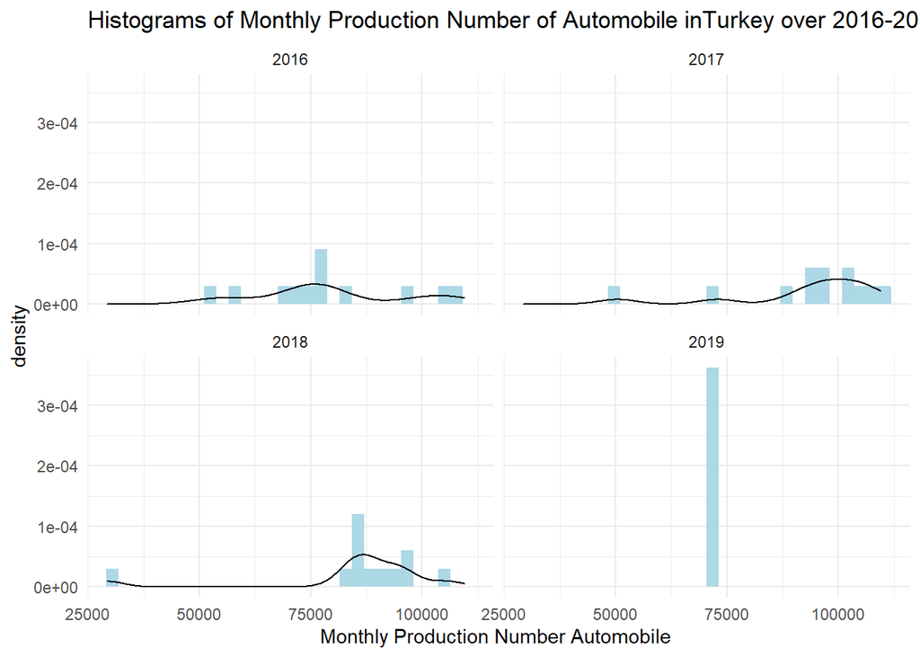

#By looking at the yearly histograms of of Monthly Production Number of Automobile in Turkey over 2016-2019, it can assumed that the samples collected in a monthly manner cannot be fitted in to a normal distribution or other distributions .

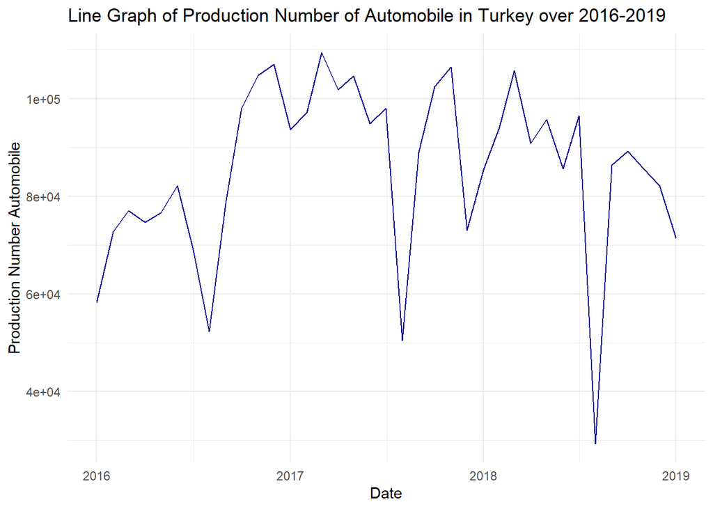

#The number of automobile produced line graphs shows us no apparent trend but but seasonality is appeared..

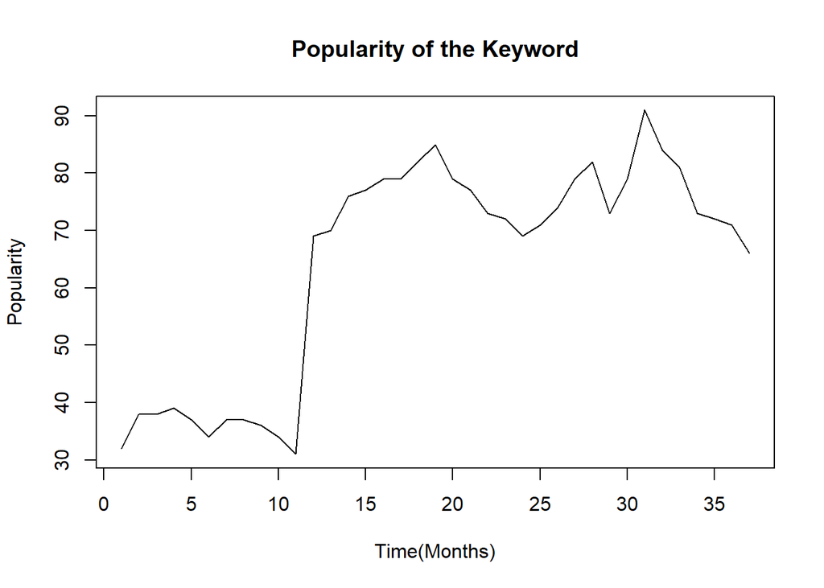

#Automobile in Turkey seems to gain popularity over years and lose some at the end. . #I chose “automobile” as google trends search keyword.

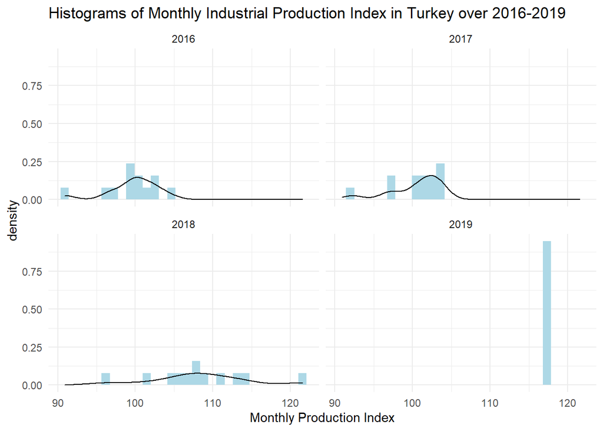

#The Histograms of Monthly Industrial Production Index in Turkey over 2016-2019 can nearly be represented via a normal distribution, except this year 2019. However, the mean values are subject to a relatively increase.

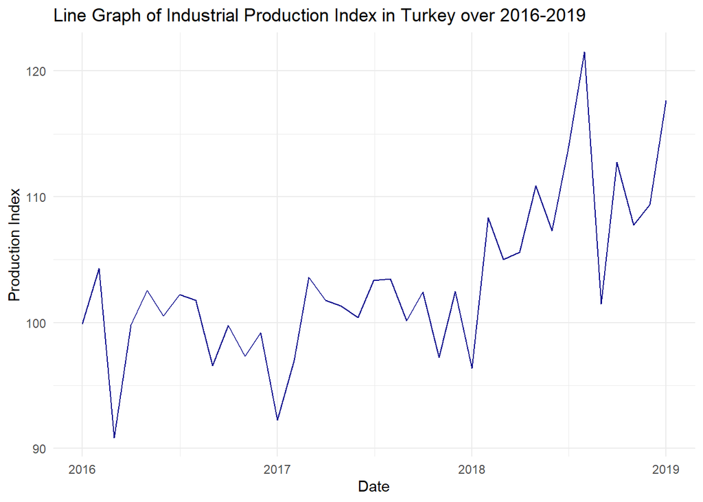

#The industrial production index line graphs shows us apparent trend after 2017 and seasonality.

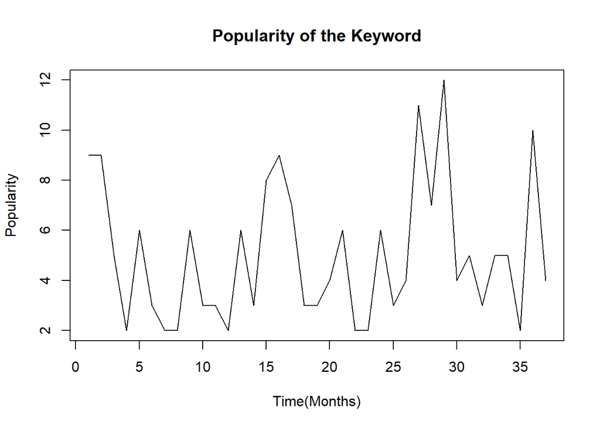

#Oil Production in Turkey tend to have a yearly cyclic behavior.. #I chose “Oil Production” as google trends search keyword.

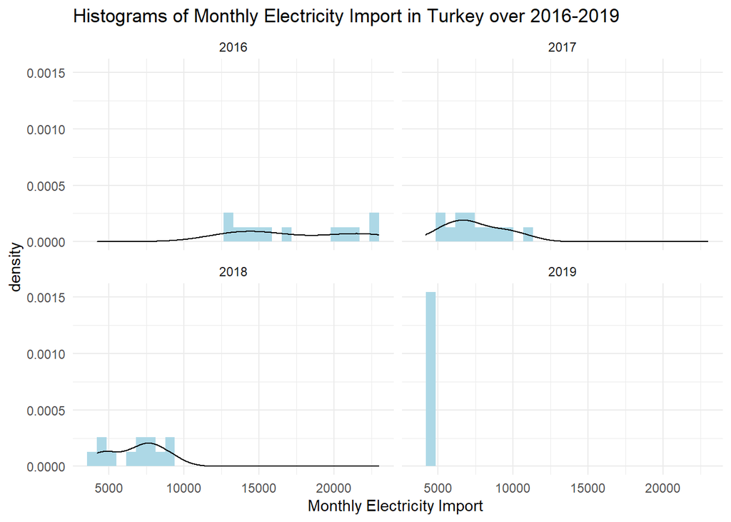

#By looking at the yearly Histograms of Monthly Electricity Import in Turkey over 2016-2019, it can assumed that the samples collected in a monthly manner cannot be fitted in to a normal distribution or other distributions

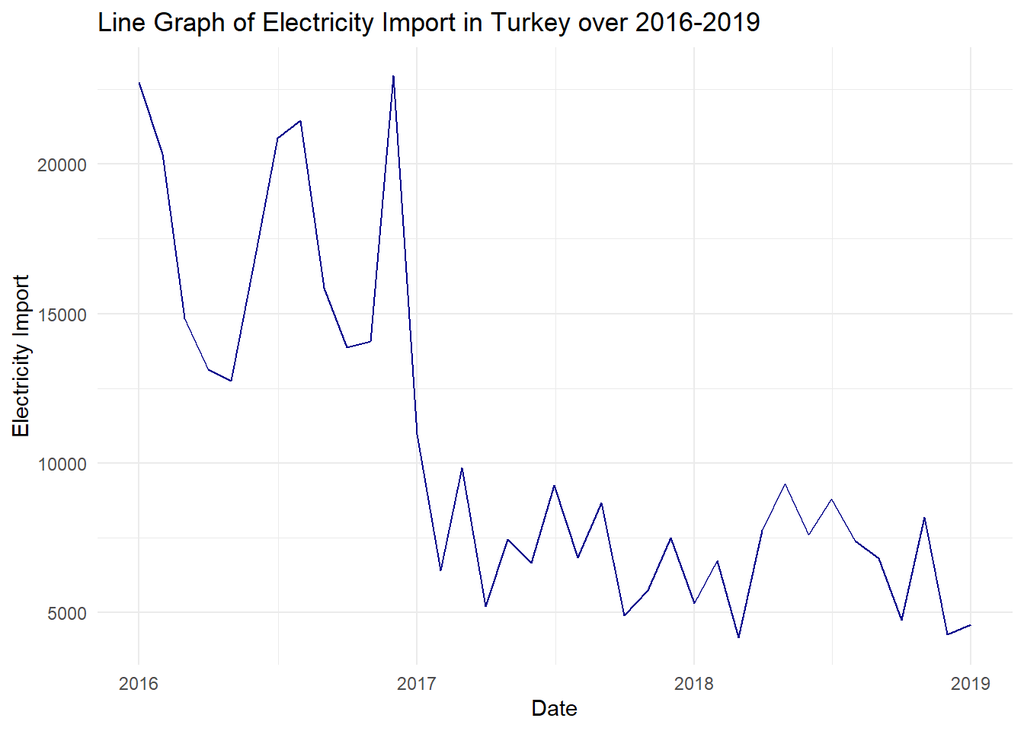

#Electricity_Import_Rate line graphs shows us apparent no trend and seasonality.After 2017 it seems to be randomly fluctuate.At the end of 2016 sudden decrease.

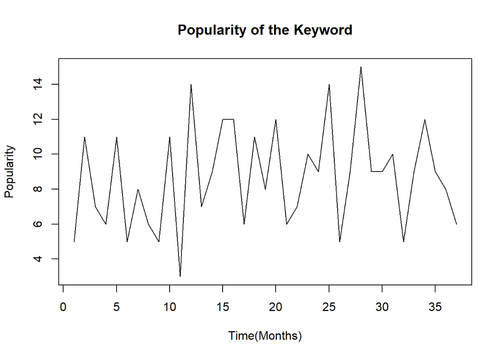

## Electricity Import Trend in Turkey tend to have a yearly cyclic behavior..

##I chose “Electricity Import” as google trends search keyword.

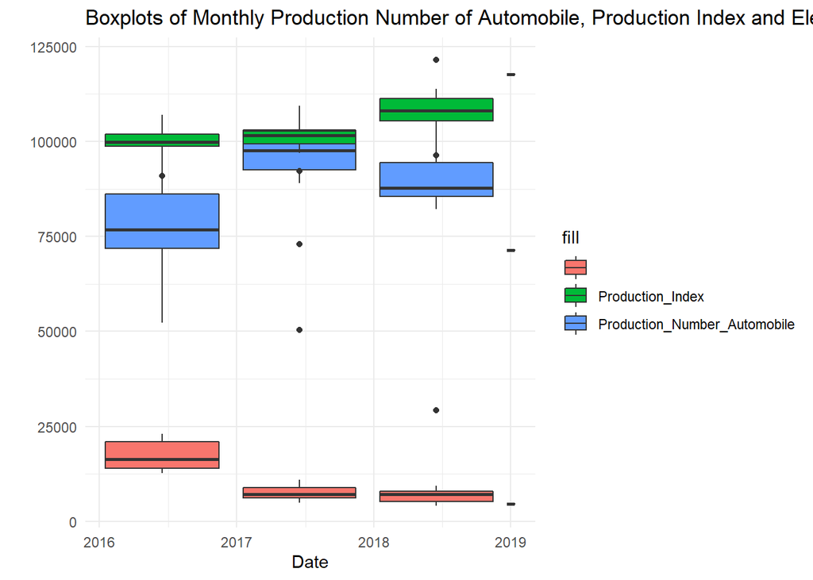

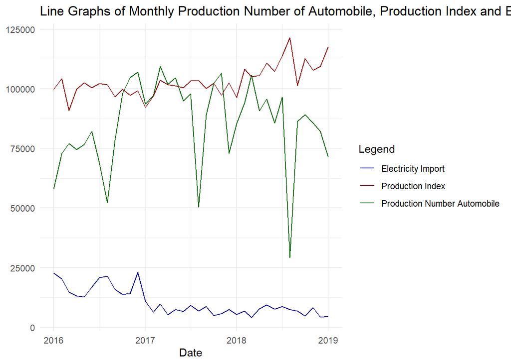